# Tutorium 13

Gruppe 2 und 4  
Samuel Teuber  
propa@teuber.dev  
https://teuber.dev/propa

## Heute: Evaluation

...gegen Ende des Tutoriums!

## Übungsblatt

### Aufgabe 1.1: Unifikation

Terme $$ X_1 = X_2\\ X_2 = X_3 $$ Substitutionen: $$ \sigma_1 = \left[X_1⇨X_2, X_2⇨X_3\right]\\ \sigma_2 = \left[X_2⇨X_3\right]\circ\left[X_1⇨X_2\right]\\ \sigma_3 = \left[X_1⇨a,X_2⇨a,X_3⇨a\right] $$

- $\sigma_2,\sigma_3$ sind Unifikatoren
- $\sigma_2$ ist **mgu**

### Aufgabe 1.2: mgu berechnen

### Aufgabe 1.3: mgu angeben

```
a([1,2,3],[3,4],L) = a([X|Xs], [Y|Ys], L2)
```

$$ \left[L⇨L2, X⇨1, Xs⇨[2,3], Y⇨3, Ys⇨[4]\right] $$

### Aufgabe 2: Lambda Terme

### Aufgabe 3: Typabstraktion

# Lexikalische Analyse

**Idee:** String -> Folge von Tokens

- Basierend auf regulären Ausdrücken
- Konstruktion von endlichen Automaten zur Erkennung von Token

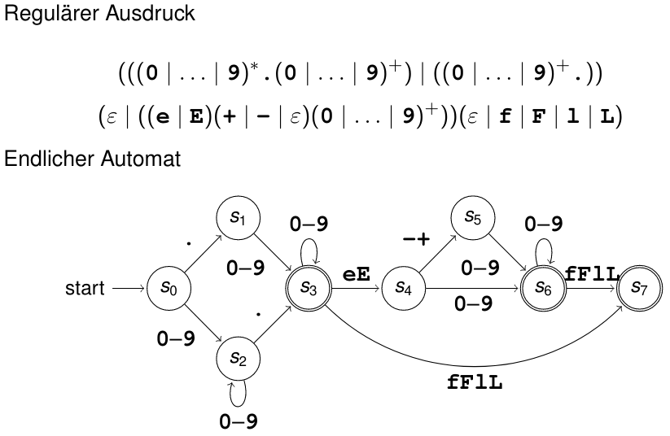

## Ergebnis der Lexikalischen Analyse

`id:X` `+` `id:Y` `*` `float:Z`

# Grammatiken und Parsing

## Was ist eine Grammatik?

Grammatik $G = \left(\Sigma, V, P, S\right)$

- $\Sigma$: endliches Alphabet
- $V$: Nichtterminale
- $S \in V$ Startsymbol
- $P$ Produktionsregeln $l\rightarrow r$ mit $l\in \left(V\cup\Sigma\right)^+, r\in \left(V\cup\Sigma\right)^*$

$w \Rightarrow z$ Anwendung einer Produktion auf $w$ ergibt $z$  
$w \Rightarrow^*z$ Anwendung einer, mehrer (oder keiner) Produktion verwandelt w in z  
$w \Rightarrow^+ z$ Anwendung mind. einer Produktion

## Weitere Begriffe

- Kontextfreie Grammatik
- Sprache $L(G)$ einer Grammatik $G$
- Linksableitung $\Rightarrow_L$
- Rechtsableitung $\Rightarrow_R$

## Beispiel

$$ P = \{ E \rightarrow \textbf{id}, E \rightarrow E \mathbf{+} E, E \rightarrow E \mathbf{\ast} E \} $$

## Abstrakter Syntaxbaum

(vs. konkreter Syntaxbaum)

Normalerweise konstruiert ein Parser den AST direkt

## Top-Down Parsing

LL: Liest einmal von **l**inks nach rechts, baut dabei **L**inksableitung auf

$$ P = \{S \rightarrow AB\\ A \rightarrow a \mid aA\\ B \rightarrow ab \} $$

**$k$-Lookahead**

**Indizmenge:** Welche Terminale sieht der Parser, wenn er sich zwischen zwei Ableitungsregeln entscheiden muss?

## $First$ and $Follow$

Für $\chi\in\Sigma^*$ ist der **$k$-Anfang** $k\colon\chi$ der Präfix der Länge $k$ von $\chi\#\#\dots$ ($\#\notin\Sigma$)

$$ First_k\left(\chi\right) = \{ \beta \mid \exists \tau \in \Sigma^*: \chi \Rightarrow^* \tau \land \beta = k \colon \tau \} $$

$$ Follow_k\left(\chi\right) = \{ \beta \mid \exists \alpha,\omega \in \left(V\cup\Sigma\right)^* \text{ mit } S \Rightarrow^* \alpha\chi\omega \land \beta \in First_k\left(\omega\right) \} $$

$$ P = \{S \rightarrow AB, A \rightarrow aA \mid a, B \rightarrow ab \mid cS\} $$

**Aufgabe**

## $SLL$-Bedingung

Eine (kontextfreie) Grammatik ist genau dann eine $SLL(k)$-Grammatik, wenn für alle Paare von Produktionen $A \rightarrow \alpha \mid \beta$ ($\alpha \neq \beta$) gilt:

$$ First_k\left(\alpha\ Follow_k\left(A\right)\right) \cap First_k\left(\beta\ Follow_k\left(A\right)\right) = \emptyset $$

### Spezialfall $k=1$

Für $\alpha \nRightarrow^* \varepsilon$ und $\beta \nRightarrow^* \varepsilon$: $$ SLL \iff First(\alpha) \cap First(\beta) = \emptyset $$

Für $\alpha \Rightarrow^* \varepsilon$ und $\beta \nRightarrow^* \varepsilon$: $$ SLL \iff First(\alpha) \cap First(\beta) = Follow(A) \cap First(\beta) = \emptyset $$

**Umfrage**

## Linksfaktorisierung

Vermeiden von gemeinsamen Nichtterminal-Anfängen:

## Parser Bau: Rekursiver Abstieg

- Eine parse-Funktion pro Grammatik-Symbol
- Jedes Symbol konsumiert seinen Teil der Eingabe

Parse-Funktion für Nichtterminal A:

- Für $SLL(1)$:

  ```
  switch (lexer.current) {...}
  ```

- In Zweig, der sich für Produktion $A \rightarrow aAB$ entscheidet:

  ```
  expect(TokenType.a);
  parseA();
  parseB();
  ```

# Evaluation

https://onlineumfrage.kit.edu/evasys/online.php?p=NS7W1